# Table of Contents

# Hello World

## print

```python
txt = 'hello world'
print (txt)
```

```
hello world
```

## python

```python
txt.upper()
```

```
'HELLO WORLD'
```

```python
newtxt = ''.join([x.upper() if random.randint(0,1)==1 else x for x in txt ])
print(newtxt)
```

```
heLlO wORLd
```

```python
for i in range(10):
    newtxt = ''.join([x.upper() if random.randint(0,1)==1 else x for x in txt ])
    print(newtxt)
```

```
hEllo WOrlD
hellO woRlD
hellO wOrLD
helLO world
HELlo wOrlD
HELLo WOrLD
HELlO wOrlD
hELlo WorLd
HeLLo WoRld
hELLo wOrLD
```

```python
import random
data = {}
for i in range(100):
    newtxt = ''.join([x.upper() if random.randint(0,1)==1 else x for x in txt ])
    data[newtxt] = random.randint(1,100)
```

```python
from wordcloud import WordCloud
wc = WordCloud(width=800, height=400, max_words=200).generate_from_frequencies(data)
```

```python
wc.to_array()
```

[output not shown]

```
(-0.5, 799.5, 399.5, -0.5)
```

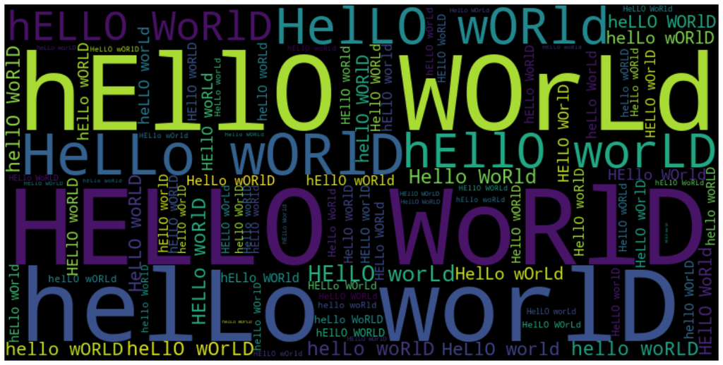

```python
import matplotlib.pyplot as plt

plt.figure(figsize=(20, 20))
plt.imshow(wc, interpolation='bilinear')
plt.axis('off')
plt.show()
```

# Plan

## Exo algo

Idee d'excercice pour creer un json a partir des données brut de ce nootebook = afficher la table of content

```python
import json
```

```python
Name = "Python.ipynb"
#Name = 'Mardown.ipynb'
with open(Name, "r") as file:
    data = json.load(file)
```

```python
L = []
D = {}
i = [0,0,0]
for x in data['cells']:
    if x['cell_type'] == 'markdown':
        cible = x['source'][0]
        cible2 = cible.replace('#' ,'')
        if  '###' in cible:
            title3 = cible2
            D[title1][title2][title3]  =  {}
        elif '##' in cible:
            title2 = cible2
            D[title1][title2] = {}
        elif '#' in cible:
            title1 = cible2
            D[title1] = {}
```

```python
print (json.dumps(D,sort_keys=False, indent=4))
```

```
{
    " Hello World": {},
    " Plan": {},
    " IMPORT": {},
    " PYTHON  PANDAS": {
        " BigPicture": {},
        " basic ": {},
        " Utils": {}
    },
    " Import Data et feature": {
        " Load": {},
        " Trie": {},
        " Columns": {},
        " Schema": {},
        " Columns selec ": {},
        " Colonne nettoyage": {},
        " Enrichissement dep to region\n": {
            " Ajout Paris": {},
            " correction Code_departement": {}
        }
    },
    " Analyse": {
        " Groupby": {},
        " Describe": {},
        " Categories ": {},
        " stack unstack": {},
        " pivot table ": {},
        " percentiles": {},
        " TimeSerie": {
            " to Date time ": {},
            " Manip dt": {},
            " rolling ": {}
        }
    },
    " Export MAXX": {
        " lambda": {},
        " function ": {},
        " swagger": {},
        " widget": {}
    },
    " Pycharm": {
        " presentation ": {},
        " export function to pycharm ": {}
    },
    " Class": {
        " basqiue": {},
        " refactorer code ": {
            " class": {},
            " module": {}
        }
    },
    " Bonne pratique": {
        " pytest": {},
        " git ": {}
    }
}
```

# IMPORT

```python
import urllib.parse

import json
import pandas as pd
import time
import numpy as np
from IPython.display import display, HTML
import matplotlib.pyplot as plt
import time
from datetime import datetime

#from pymongo import MongoClient
import glob, os

%matplotlib inline
```

```python
%config Completer.use_jedi = False
```

```python
# pour permettre d'afficher plusieurs df en meme temps
from IPython.core.interactiveshell import InteractiveShell
InteractiveShell.ast_node_interactivity = "all"
```

```python
from IPython.core.display import display, HTML
display(HTML("<style>.container { width:80%! important; }</style>"))
```

# Python / Pandas

## BigPicture

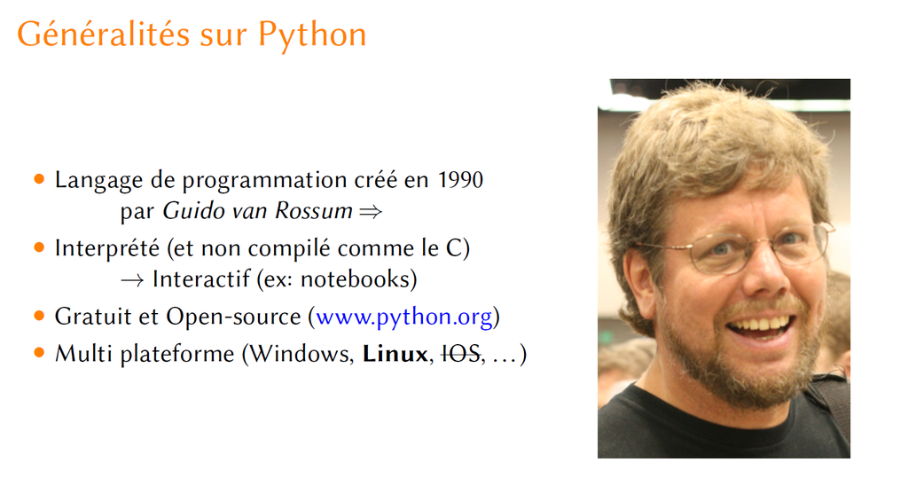

```python
from IPython.display import Image
Image("2020-02-13_1701.png", width=700)
```

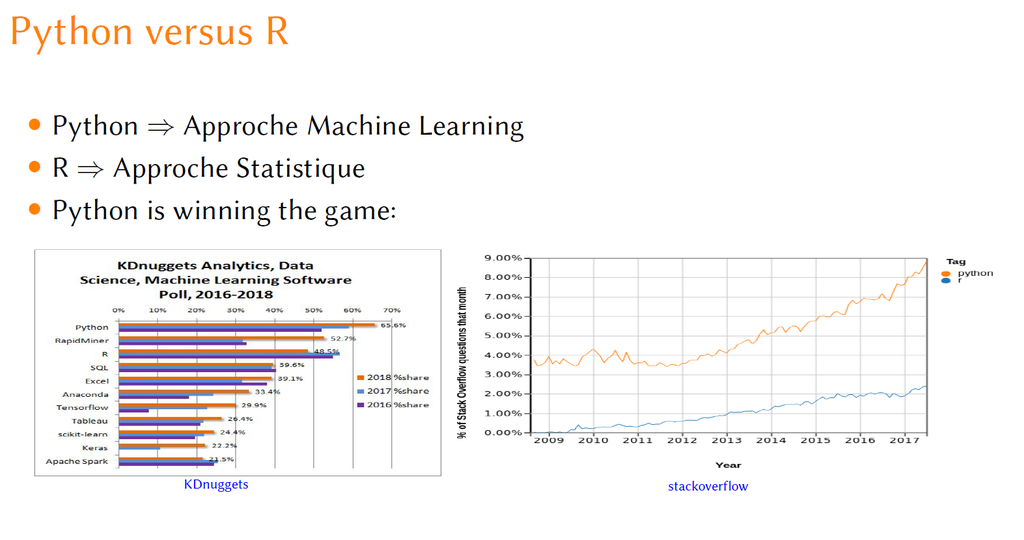

```python
Image("2020-02-13_1705.png", width=700)
```

## Liens utile / ressources

### Doc python / pandas

the master https://wesmckinney.com/pages/about.html

les cours https://github.com/wesm/pydata-book

incontournable : http://sametmax.com/ce-quil-faut-savoir-en-python/

### Doc Maxx

## basic Python

```python
# Listes
# 1) Créer une liste d'entiers d'au moins 10 éléments et afficher la taille de la liste
l = [5,8,9,5,4,9,3,9,3,0,5,3]
print(len(l))

# 2) Afficher du 3eme au 5eme élément de la liste (en une ligne de code)
print(l[2:5])

# 3) Ajouter un nombre réel à cette liste et afficher la liste
l.append(236.6)
print(l)

# 4) Afficher la plus faible valeur de la liste (Sans modifier la liste)
print(sorted(l)[0])

# String
s = "This is a totaly random sentence."
print(s)

# 1) Retirer le mot 'totaly' de la phrase et afficher la nouvelle phrase
s = s.replace('totaly ', '')
print(s)

# 2) Créer une liste contenant tout les mots de la phrase (sans la ponctuation) et l'afficher
l = s[:-1].split(' ')
print(l)

# Dictionnaries and Loop
d = {'a': 5, 'g':8.89, 9: ['a', 2, 3], 7: "hello"}

# 1) afficher la liste des clés
print(d.keys())

# 2) Utiliser une boucle pour afficher une phrase contenant la clé
#    et la valeur correspondantes pour tous les éléments du dictionnaire
for k, v in d.items():
    print("La clé {} contient la valeur {}".format(k, v))

# 3) Dans la boucle précédante, ajouter une phrase spécifique lorsque la valeur 5 est trouvée
for k, v in d.items():
    if v == 5:
        print("C'est la valeur {} pour la clé {}!".format(v, k))
    else:
        print("La clé {} contient la valeur {}".format(k, v))
```

```python
a = 2

a

b=3

a*b

List = [2,3,5]

Sum = 0
for i in List:
    Sum = Sum + i

Sum

list('abc')

Dict = {'a': 2, 'b': 3, 'c': 5}

for key, value in Dict.items():
    print (key, value)

Sum = 0
for key, value in Dict.items():
    Sum = Sum + value
Sum
```

```python
dict(zip(list('abc'), [2,3,5]))

sum([v for k,v in Dict.items()])
```

## Basic Pandas

## Utils

### tqdm

```python
import tqdm
import time

for i in tqdm.tqdm(range(100)):
    time.sleep(0.01)
```

### time

```python
import time
t = time.time()

time.strftime('%Y-%m-%d %H:%M %Z', time.localtime(t))
```

```
'2020-02-26 21:19 Paris, Madrid'
```

```python
import datetime
datetime.datetime.utcnow()
```

```
datetime.datetime(2020, 2, 26, 16, 13, 16, 21864)
```

### Glob

```python
import glob
path = 'img/*.*'
glob.glob(path)
```

```
['img\\2020-02-13_1701.png',
 'img\\2020-02-13_1705.png',
 'img\\NotebookShortcut.png']
```

# Data manipulation

https://www.data.gouv.fr/fr/datasets/demandes-de-valeurs-foncieres-geolocalisees/

## Load

```python
path = 'Data\*.txt'
Filelist = [p for p in glob.glob(path)]
Filelist
```

```
['Data\\valeursfoncieres-2018.txt', 'Data\\valeursfoncieres-2019.txt']
```

```python
%%time
file = Filelist[1]
df = pd.read_csv(file, sep="|", error_bad_lines=False)
```

```
Wall time: 4.5 s
```

```python
df.shape
```

[output not shown]

```python
df.head()
```

|  | Code service CH | Reference document | 1 Articles CGI | 2 Articles CGI | 3 Articles CGI | 4 Articles CGI | 5 Articles CGI | No disposition | Date mutation | Nature mutation | ... | Surface Carrez du 5eme lot | Nombre de lots | Code type local | Type local | Identifiant local | Surface reelle bati | Nombre pieces principales | Nature culture | Nature culture speciale | Surface terrain |
| --- | --- | --- | --- | --- | --- | --- | --- | --- | --- | --- | --- | --- | --- | --- | --- | --- | --- | --- | --- | --- | --- |
| 0 | NaN | NaN | NaN | NaN | NaN | NaN | NaN | 1 | 11/01/2019 | Vente | ... | NaN | 1 | 3.0 | Dépendance | NaN | 0.0 | 0.0 | NaN | NaN | NaN |
| 1 | NaN | NaN | NaN | NaN | NaN | NaN | NaN | 1 | 11/01/2019 | Vente | ... | NaN | 2 | 2.0 | Appartement | NaN | 67.0 | 3.0 | NaN | NaN | NaN |
| 2 | NaN | NaN | NaN | NaN | NaN | NaN | NaN | 1 | 08/02/2019 | Vente | ... | NaN | 0 | 1.0 | Maison | NaN | 118.0 | 4.0 | AG | PARC | 913.0 |
| 3 | NaN | NaN | NaN | NaN | NaN | NaN | NaN | 1 | 08/02/2019 | Vente | ... | NaN | 0 | 1.0 | Maison | NaN | 118.0 | 4.0 | S | NaN | 1000.0 |
| 4 | NaN | NaN | NaN | NaN | NaN | NaN | NaN | 1 | 04/04/2019 | Vente | ... | NaN | 0 | 1.0 | Maison | NaN | 60.0 | 3.0 | S | NaN | 96.0 |

5 rows × 43 columns

```python
df.to_pickle('df')
```

## Trie

```python
%%time
df = pd.read_pickle('df')
```

```
Wall time: 2.75 s
```

```python
a = (df.isnull().sum()/df.shape[0]).round(2)
```

```python
df.columns
```

```
Index(['Code service CH', 'Reference document', '1 Articles CGI',
       '2 Articles CGI', '3 Articles CGI', '4 Articles CGI', '5 Articles CGI',
       'No disposition', 'Date mutation', 'Nature mutation', 'Valeur fonciere',
       'No voie', 'B/T/Q', 'Type de voie', 'Code voie', 'Voie', 'Code postal',
       'Commune', 'Code departement', 'Code commune', 'Prefixe de section',
       'Section', 'No plan', 'No Volume', '1er lot',
       'Surface Carrez du 1er lot', '2eme lot', 'Surface Carrez du 2eme lot',
       '3eme lot', 'Surface Carrez du 3eme lot', '4eme lot',
       'Surface Carrez du 4eme lot', '5eme lot', 'Surface Carrez du 5eme lot',
       'Nombre de lots', 'Code type local', 'Type local', 'Identifiant local',
       'Surface reelle bati', 'Nombre pieces principales', 'Nature culture',
       'Nature culture speciale', 'Surface terrain'],
      dtype='object')
```

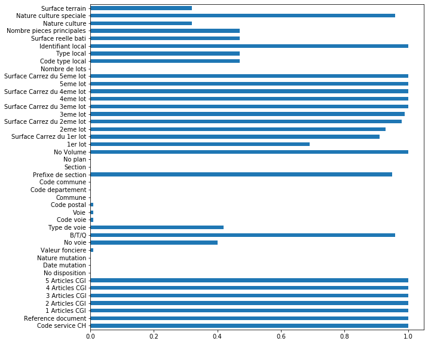

```python
a.plot.barh(figsize = (10,10))
```

```python
df = df.dropna(axis=1,how='all')
df.shape
```

```
(1017154, 35)
```

```python
pd.set_option('display.max_colwidth', -1)
```

## Selec colonnes non null

```python
dfc = (df.isnull().sum()/df.shape[0]).round(2)
```

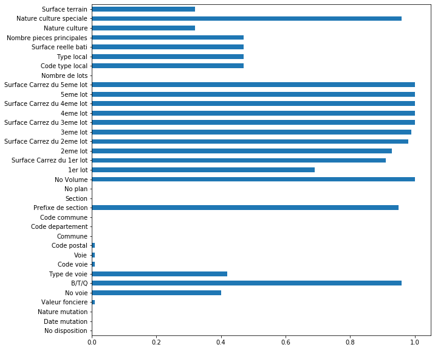

```python
dfc.plot.barh(figsize = (10,10))
```

```python
dfc.index = dfc.index.str.replace(' ','_')
```

```python
dfc
```

```
No_disposition                0.00
Date_mutation                 0.00
Nature_mutation               0.00
Valeur_fonciere               0.01
No_voie                       0.40
B/T/Q                         0.96
Type_de_voie                  0.42
Code_voie                     0.01
Voie                          0.01
Code_postal                   0.01
Commune                       0.00
Code_departement              0.00
Code_commune                  0.00
Prefixe_de_section            0.95
Section                       0.00
No_plan                       0.00
No_Volume                     1.00
1er_lot                       0.69
Surface_Carrez_du_1er_lot     0.91
2eme_lot                      0.93
Surface_Carrez_du_2eme_lot    0.98
3eme_lot                      0.99
Surface_Carrez_du_3eme_lot    1.00
4eme_lot                      1.00
Surface_Carrez_du_4eme_lot    1.00
5eme_lot                      1.00
Surface_Carrez_du_5eme_lot    1.00
Nombre_de_lots                0.00
Code_type_local               0.47
Type_local                    0.47
Surface_reelle_bati           0.47
Nombre_pieces_principales     0.47
Nature_culture                0.32
Nature_culture_speciale       0.96
Surface_terrain               0.32
dtype: float64
```

```python
df.columns = dfc.index
```

```python
df = df[dfc[dfc< 0.9].index]
```

```python
df.shape
```

```
(1017154, 22)
```

```python
df.to_pickle('df')
```

```python
df
```

|  | No_disposition | Date_mutation | Nature_mutation | Valeur_fonciere | No_voie | Type_de_voie | Code_voie | Voie | Code_postal | Commune | ... | Section | No_plan | 1er_lot | Nombre_de_lots | Code_type_local | Type_local | Surface_reelle_bati | Nombre_pieces_principales | Nature_culture | Surface_terrain |
| --- | --- | --- | --- | --- | --- | --- | --- | --- | --- | --- | --- | --- | --- | --- | --- | --- | --- | --- | --- | --- | --- |
| 0 | 1 | 11/01/2019 | Vente | 84000,00 | 552.0 | AV | 0260 | DE LYON | 1960.0 | PERONNAS | ... | AD | 226 | 44 | 1 | 3.0 | Dépendance | 0.0 | 0.0 | NaN | NaN |
| 1 | 1 | 11/01/2019 | Vente | 84000,00 | 552.0 | AV | 0260 | DE LYON | 1960.0 | PERONNAS | ... | AD | 226 | 1 | 2 | 2.0 | Appartement | 67.0 | 3.0 | NaN | NaN |
| 2 | 1 | 08/02/2019 | Vente | 210000,00 | 5189.0 | NaN | B041 | LE METRILLOT | 1250.0 | MONTAGNAT | ... | BB | 23 | NaN | 0 | 1.0 | Maison | 118.0 | 4.0 | AG | 913.0 |
| 3 | 1 | 08/02/2019 | Vente | 210000,00 | 5189.0 | NaN | B041 | LE METRILLOT | 1250.0 | MONTAGNAT | ... | BB | 23 | NaN | 0 | 1.0 | Maison | 118.0 | 4.0 | S | 1000.0 |
| 4 | 1 | 04/04/2019 | Vente | 36000,00 | 40.0 | PL | 0090 | DE LA FONTAINE | 1560.0 | SAINT-JULIEN-SUR-REYSSOUZE | ... | A | 138 | NaN | 0 | 1.0 | Maison | 60.0 | 3.0 | S | 96.0 |
| ... | ... | ... | ... | ... | ... | ... | ... | ... | ... | ... | ... | ... | ... | ... | ... | ... | ... | ... | ... | ... | ... |
| 1017149 | 1 | 27/06/2019 | Vente | 46000000,00 | 12.0 | RUE | 6998 | DE LA PAIX | 75002.0 | PARIS 02 | ... | AB | 51 | NaN | 0 | 4.0 | Local industriel. commercial ou assimilé | 120.0 | 0.0 | S | 720.0 |
| 1017150 | 1 | 27/06/2019 | Vente | 46000000,00 | 12.0 | RUE | 6998 | DE LA PAIX | 75002.0 | PARIS 02 | ... | AB | 51 | NaN | 0 | 4.0 | Local industriel. commercial ou assimilé | 240.0 | 0.0 | S | 720.0 |
| 1017151 | 1 | 27/06/2019 | Vente | 46000000,00 | 12.0 | RUE | 6998 | DE LA PAIX | 75002.0 | PARIS 02 | ... | AB | 51 | NaN | 0 | 4.0 | Local industriel. commercial ou assimilé | 251.0 | 0.0 | S | 720.0 |
| 1017152 | 1 | 27/06/2019 | Vente | 46000000,00 | 12.0 | RUE | 6998 | DE LA PAIX | 75002.0 | PARIS 02 | ... | AB | 51 | NaN | 0 | 4.0 | Local industriel. commercial ou assimilé | 118.0 | 0.0 | S | 720.0 |
| 1017153 | 1 | 27/06/2019 | Vente | 46000000,00 | 12.0 | RUE | 6998 | DE LA PAIX | 75002.0 | PARIS 02 | ... | AB | 51 | NaN | 0 | 4.0 | Local industriel. commercial ou assimilé | 123.0 | 0.0 | S | 720.0 |

1017154 rows × 22 columns

## Enrichissement I (docstring): schema

```python
txt = '''id_mutation : Identifiant de mutation (non stable, sert à grouper les lignes)
    date_mutation : Date de la mutation au format ISO-8601 (YYYY-MM-DD)
    numero_disposition : Numéro de disposition
    valeur_fonciere : Valeur foncière (séparateur décimal = point)
    adresse_numero : Numéro de l'adresse
    adresse_suffixe : Suffixe du numéro de l'adresse (B, T, Q)
    adresse_code_voie : Code FANTOIR de la voie (4 caractères)
    adresse_nom_voie : Nom de la voie de l'adresse
    code_postal : Code postal (5 caractères)
    code_commune : Code commune INSEE (5 caractères)
    nom_commune : Nom de la commune (accentué)
    ancien_code_commune : Ancien code commune INSEE (si différent lors de la mutation)
    ancien_nom_commune : Ancien nom de la commune (si différent lors de la mutation)
    code_departement : Code département INSEE (2 ou 3 caractères)
    id_parcelle : Identifiant de parcelle (14 caractères)
    ancien_id_parcelle : Ancien identifiant de parcelle (si différent lors de la mutation)
    numero_volume : Numéro de volume
    lot_1_numero : Numéro du lot 1
    lot_1_surface_carrez : Surface Carrez du lot 1
    lot_2_numero : Numéro du lot 2
    lot_2_surface_carrez : Surface Carrez du lot 2
    lot_3_numero : Numéro du lot 3
    lot_3_surface_carrez : Surface Carrez du lot 3
    lot_4_numero : Numéro du lot 4
    lot_4_surface_carrez : Surface Carrez du lot 4
    lot_5_numero : Numéro du lot 5
    lot_5_surface_carrez : Surface Carrez du lot 5
    nombre_lots : Nombre de lots
    code_type_local : Code de type de local
    type_local : Libellé du type de local
    surface_reelle_bati : Surface réelle du bâti
    nombre_pieces_principales : Nombre de pièces principales
    code_nature_culture : Code de nature de culture
    nature_culture : Libellé de nature de culture
    code_nature_culture_speciale : Code de nature de culture spéciale
    nature_culture_speciale : Libellé de nature de culture spéciale
    surface_terrain : Surface du terrain
    longitude : Longitude du centre de la parcelle concernée (WGS-84)
    latitude : Latitude du centre de la parcelle concernée (WGS-84)'''
```

```python
Sc = pd.Series(txt.split('\n')).str.split(':').apply(pd.Series).rename(columns = {0:'vars', 1:'description'})#.set_index('vars').description
```

```python
Sc
```

|  | vars | description |
| --- | --- | --- |
| 0 | id_mutation | Identifiant de mutation (non stable, sert à g... |
| 1 | date_mutation | Date de la mutation au format ISO-8601 (YYYY-... |
| 2 | numero_disposition | Numéro de disposition |
| 3 | valeur_fonciere | Valeur foncière (séparateur décimal = point) |
| 4 | adresse_numero | Numéro de l'adresse |
| 5 | adresse_suffixe | Suffixe du numéro de l'adresse (B, T, Q) |
| 6 | adresse_code_voie | Code FANTOIR de la voie (4 caractères) |
| 7 | adresse_nom_voie | Nom de la voie de l'adresse |
| 8 | code_postal | Code postal (5 caractères) |
| 9 | code_commune | Code commune INSEE (5 caractères) |
| 10 | nom_commune | Nom de la commune (accentué) |
| 11 | ancien_code_commune | Ancien code commune INSEE (si différent lors ... |
| 12 | ancien_nom_commune | Ancien nom de la commune (si différent lors d... |
| 13 | code_departement | Code département INSEE (2 ou 3 caractères) |
| 14 | id_parcelle | Identifiant de parcelle (14 caractères) |
| 15 | ancien_id_parcelle | Ancien identifiant de parcelle (si différent ... |
| 16 | numero_volume | Numéro de volume |
| 17 | lot_1_numero | Numéro du lot 1 |
| 18 | lot_1_surface_carrez | Surface Carrez du lot 1 |
| 19 | lot_2_numero | Numéro du lot 2 |
| 20 | lot_2_surface_carrez | Surface Carrez du lot 2 |
| 21 | lot_3_numero | Numéro du lot 3 |
| 22 | lot_3_surface_carrez | Surface Carrez du lot 3 |
| 23 | lot_4_numero | Numéro du lot 4 |
| 24 | lot_4_surface_carrez | Surface Carrez du lot 4 |
| 25 | lot_5_numero | Numéro du lot 5 |
| 26 | lot_5_surface_carrez | Surface Carrez du lot 5 |
| 27 | nombre_lots | Nombre de lots |
| 28 | code_type_local | Code de type de local |
| 29 | type_local | Libellé du type de local |
| 30 | surface_reelle_bati | Surface réelle du bâti |
| 31 | nombre_pieces_principales | Nombre de pièces principales |
| 32 | code_nature_culture | Code de nature de culture |
| 33 | nature_culture | Libellé de nature de culture |
| 34 | code_nature_culture_speciale | Code de nature de culture spéciale |
| 35 | nature_culture_speciale | Libellé de nature de culture spéciale |
| 36 | surface_terrain | Surface du terrain |
| 37 | longitude | Longitude du centre de la parcelle concernée ... |
| 38 | latitude | Latitude du centre de la parcelle concernée (... |

```python
Sc.vars.apply(lambd)
```

```python
df.columns
```

[output not shown]

## Selec colonnes

```python
txt = '''Date mutation
Valeur fonciere
Code postal
Commune
Code departement
Code commune
Surface reelle bati
Nombre pieces principales
Surface terrain'''
```

```python
s = pd.Series(txt.split('\n')).str.replace(' ','_')
s
```

```
0    Date_mutation
1    Valeur_fonciere
2    Code_postal
3    Commune
4    Code_departement
5    Code_commune
6    Surface_reelle_bati
7    Nombre_pieces_principales
8    Surface_terrain
dtype: object
```

```python
df.columns
```

```
Index(['No_disposition', 'Date_mutation', 'Nature_mutation', 'Valeur_fonciere',
       'No_voie', 'Type_de_voie', 'Code_voie', 'Voie', 'Code_postal',
       'Commune', 'Code_departement', 'Code_commune', 'Section', 'No_plan',
       '1er_lot', 'Nombre_de_lots', 'Code_type_local', 'Type_local',
       'Surface_reelle_bati', 'Nombre_pieces_principales', 'Nature_culture',
       'Surface_terrain'],
      dtype='object')
```

```python
s.isin(df.columns)
```

```
0    True
1    True
2    True
3    True
4    True
5    True
6    True
7    True
8    True
dtype: bool
```

```python
df = df[s.values]
```

```python
df.shape
```

```
(1017154, 9)
```

```python
df.to_pickle('df')
```

## format data

```python
df = pd.read_pickle('df')
df.shape
```

```
(1017154, 9)
```

```python
df.head()
```

|  | Date_mutation | Valeur_fonciere | Code_postal | Commune | Code_departement | Code_commune | Surface_reelle_bati | Nombre_pieces_principales | Surface_terrain |
| --- | --- | --- | --- | --- | --- | --- | --- | --- | --- |
| 0 | 11/01/2019 | 84000,00 | 1960.0 | PERONNAS | 1 | 289 | 0.0 | 0.0 | NaN |
| 1 | 11/01/2019 | 84000,00 | 1960.0 | PERONNAS | 1 | 289 | 67.0 | 3.0 | NaN |
| 2 | 08/02/2019 | 210000,00 | 1250.0 | MONTAGNAT | 1 | 254 | 118.0 | 4.0 | 913.0 |
| 3 | 08/02/2019 | 210000,00 | 1250.0 | MONTAGNAT | 1 | 254 | 118.0 | 4.0 | 1000.0 |
| 4 | 04/04/2019 | 36000,00 | 1560.0 | SAINT-JULIEN-SUR-REYSSOUZE | 1 | 367 | 60.0 | 3.0 | 96.0 |

```python
df.apply(np.dtype)
```

```
Date_mutation                object
Valeur_fonciere              object
Code_postal                  object
Commune                      object
Code_departement             object
Code_commune                 object
Surface_reelle_bati          object
Nombre_pieces_principales    object
Surface_terrain              object
dtype: object
```

```python
dftype = pd.DataFrame([df[c].apply(type).value_counts() for c in df.columns])
```

```python
dftype
```

[output not shown]

```python
df.Valeur_fonciere = pd.to_numeric(df.Valeur_fonciere[df.Valeur_fonciere.apply(type) == str].str.split(',').str[0])
```

```python
df.Valeur_fonciere[df.Valeur_fonciere.apply(type) != str]
```

```
0             84000.0
1             84000.0
2            210000.0
3            210000.0
4             36000.0
              ...
1017149    46000000.0
1017150    46000000.0
1017151    46000000.0
1017152    46000000.0
1017153    46000000.0
Name: Valeur_fonciere, Length: 1017154, dtype: float64
```

```python
for c in df.columns.drop(['Date_mutation' , 'Commune']):
    print (c)
    df[c] = pd.to_numeric(df[c], errors='coerce')
```

```
Valeur_fonciere
Code_postal
Code_departement
Code_commune
Surface_reelle_bati
Nombre_pieces_principales
Surface_terrain
```

```python
df.head()
```

|  | Date_mutation | Valeur_fonciere | Code_postal | Commune | Code_departement | Code_commune | Surface_reelle_bati | Nombre_pieces_principales | Surface_terrain |
| --- | --- | --- | --- | --- | --- | --- | --- | --- | --- |
| 0 | 11/01/2019 | 84000.0 | 1960.0 | PERONNAS | 1.0 | 289 | 0.0 | 0.0 | NaN |
| 1 | 11/01/2019 | 84000.0 | 1960.0 | PERONNAS | 1.0 | 289 | 67.0 | 3.0 | NaN |
| 2 | 08/02/2019 | 210000.0 | 1250.0 | MONTAGNAT | 1.0 | 254 | 118.0 | 4.0 | 913.0 |
| 3 | 08/02/2019 | 210000.0 | 1250.0 | MONTAGNAT | 1.0 | 254 | 118.0 | 4.0 | 1000.0 |
| 4 | 04/04/2019 | 36000.0 | 1560.0 | SAINT-JULIEN-SUR-REYSSOUZE | 1.0 | 367 | 60.0 | 3.0 | 96.0 |

df.Valeur_fonciere[df.Valeur_fonciere.apply(type) == str]

```python
df.to_pickle('df')
```

## Enrichissement II (merge): region

merge et problematique index

```python
df = pd.read_pickle('df')
df.shape
```

```
(1016090, 10)
```

```python
df.isnull().sum()
```

```
Date_mutation                     0
Valeur_fonciere               12785
Code_postal                   12146
Commune                           0
Code_departement                  0
Code_commune                      0
Surface_reelle_bati          476140
Nombre_pieces_principales    476140
Surface_terrain              321061
Region                            0
dtype: int64
```

```python
df = df[df.Code_departement.notnull()]
```

```python
df.head()
```

|  | Date_mutation | Valeur_fonciere | Code_postal | Commune | Code_departement | Code_commune | Surface_reelle_bati | Nombre_pieces_principales | Surface_terrain | Region |
| --- | --- | --- | --- | --- | --- | --- | --- | --- | --- | --- |
| 0 | 11/01/2019 | 84000.0 | 1960.0 | PERONNAS | 01 | 289 | 0.0 | 0.0 | NaN | Auvergne-Rhône-Alpes |
| 1 | 11/01/2019 | 84000.0 | 1960.0 | PERONNAS | 01 | 289 | 67.0 | 3.0 | NaN | Auvergne-Rhône-Alpes |
| 2 | 08/02/2019 | 210000.0 | 1250.0 | MONTAGNAT | 01 | 254 | 118.0 | 4.0 | 913.0 | Auvergne-Rhône-Alpes |
| 3 | 08/02/2019 | 210000.0 | 1250.0 | MONTAGNAT | 01 | 254 | 118.0 | 4.0 | 1000.0 | Auvergne-Rhône-Alpes |
| 4 | 04/04/2019 | 36000.0 | 1560.0 | SAINT-JULIEN-SUR-REYSSOUZE | 01 | 367 | 60.0 | 3.0 | 96.0 | Auvergne-Rhône-Alpes |

https://www.google.com/url?sa=t&rct=j&q=&esrc=s&source=web&cd=1&ved=2ahUKEwi3jL-HwurnAhVFzRoKHWklBVQQFjAAegQIAxAB&url=https%3A%2F%2Fwww.data.gouv.fr%2Ffr%2Fdatasets%2Fregions-departements-villes-et-villages-de-france-et-doutre-mer%2F&usg=AOvVaw3wxiIerUptdSJR6SOmfrX_

```python
dfgeo = pd.read_csv('departements-france.csv')
dfgeo
dfgeo.shape
```

|  | code_departement | nom_departement | code_region | nom_region |
| --- | --- | --- | --- | --- |
| 0 | 01 | Ain | 84 | Auvergne-Rhône-Alpes |
| 1 | 02 | Aisne | 32 | Hauts-de-France |
| 2 | 03 | Allier | 84 | Auvergne-Rhône-Alpes |
| 3 | 04 | Alpes-de-Haute-Provence | 93 | Provence-Alpes-Côte d'Azur |
| 4 | 05 | Hautes-Alpes | 93 | Provence-Alpes-Côte d'Azur |
| ... | ... | ... | ... | ... |
| 95 | 971 | Guadeloupe | 1 | Guadeloupe |
| 96 | 972 | Martinique | 2 | Martinique |
| 97 | 973 | Guyane | 3 | Guyane |
| 98 | 974 | La Réunion | 4 | La Réunion |
| 99 | 976 | Mayotte | 6 | Mayotte |

100 rows × 4 columns

```
(100, 4)
```

manque paris !!!!!

### Ajout Paris

```python
dfgeo.loc[100] = ['75', 'Paris', '11', 'Île-de-France']
```

```python
dfgeo[dfgeo.nom_region == 'Île-de-France']
```

|  | code_departement | nom_departement | code_region | nom_region |
| --- | --- | --- | --- | --- |
| 76 | 77 | Seine-et-Marne | 11 | Île-de-France |
| 77 | 78 | Yvelines | 11 | Île-de-France |
| 90 | 91 | Essonne | 11 | Île-de-France |
| 91 | 92 | Hauts-de-Seine | 11 | Île-de-France |
| 92 | 93 | Seine-Saint-Denis | 11 | Île-de-France |
| 93 | 94 | Val-de-Marne | 11 | Île-de-France |
| 94 | 95 | Val-d'Oise | 11 | Île-de-France |
| 100 | 75 | Paris | 11 | Île-de-France |

```python
dfgeo.code_departement.nunique()
```

```
101
```

```python
dfgeo.set_index('code_departement')['nom_region']
```

```
code_departement
01           Auvergne-Rhône-Alpes
02                Hauts-de-France
03           Auvergne-Rhône-Alpes
04     Provence-Alpes-Côte d'Azur
05     Provence-Alpes-Côte d'Azur
                  ...
972                    Martinique
973                        Guyane
974                    La Réunion
976                       Mayotte
75                  Île-de-France
Name: nom_region, Length: 101, dtype: object
```

### correction Code_departement

les dep avec la valeur ,1,2 .... => 01, 02 ....

```python
cd = df[df.Code_departement.notnull()].Code_departement.astype(int).astype(str).copy()
```

```python
cd.apply(len).value_counts()
```

```
2    954112
1     59330
3      2648
Name: Code_departement, dtype: int64
```

cd = cd.astype(str)

```python
mask = cd.apply(len)==1
cd[mask] = cd[mask].apply(lambda x : '0'+x)
```

```python
df.loc[cd.index, 'Code_departement'] = cd
```

```python
df.head()
```

|  | Date_mutation | Valeur_fonciere | Code_postal | Commune | Code_departement | Code_commune | Surface_reelle_bati | Nombre_pieces_principales | Surface_terrain | Region | code_region |
| --- | --- | --- | --- | --- | --- | --- | --- | --- | --- | --- | --- |
| 0 | 11/01/2019 | 84000.0 | 1960.0 | PERONNAS | 01 | 289 | 0.0 | 0.0 | NaN | Auvergne-Rhône-Alpes | 84.0 |
| 1 | 11/01/2019 | 84000.0 | 1960.0 | PERONNAS | 01 | 289 | 67.0 | 3.0 | NaN | Auvergne-Rhône-Alpes | 84.0 |
| 2 | 08/02/2019 | 210000.0 | 1250.0 | MONTAGNAT | 01 | 254 | 118.0 | 4.0 | 913.0 | Auvergne-Rhône-Alpes | 84.0 |
| 3 | 08/02/2019 | 210000.0 | 1250.0 | MONTAGNAT | 01 | 254 | 118.0 | 4.0 | 1000.0 | Auvergne-Rhône-Alpes | 84.0 |
| 4 | 04/04/2019 | 36000.0 | 1560.0 | SAINT-JULIEN-SUR-REYSSOUZE | 01 | 367 | 60.0 | 3.0 | 96.0 | Auvergne-Rhône-Alpes | 84.0 |

```python
df['Region'] = df.Code_departement.map(dfgeo.set_index('code_departement')['nom_region'])
df['code_region'] = df.Code_departement.map(dfgeo.set_index('code_departement')['code_region'])
```

```python
df[df.Region.isna()].Code_departement.value_counts()
```

```
Series([], Name: Code_departement, dtype: int64)
```

```python
df.to_pickle('df')
```

# export data

```python
df = pd.read_pickle('df')
df.shape
df.head()
```

```
(1016090, 11)
```

|  | Date_mutation | Valeur_fonciere | Code_postal | Commune | Code_departement | Code_commune | Surface_reelle_bati | Nombre_pieces_principales | Surface_terrain | Region | code_region |
| --- | --- | --- | --- | --- | --- | --- | --- | --- | --- | --- | --- |
| 0 | 11/01/2019 | 84000.0 | 1960.0 | PERONNAS | 01 | 289 | 0.0 | 0.0 | NaN | Auvergne-Rhône-Alpes | 84 |
| 1 | 11/01/2019 | 84000.0 | 1960.0 | PERONNAS | 01 | 289 | 67.0 | 3.0 | NaN | Auvergne-Rhône-Alpes | 84 |
| 2 | 08/02/2019 | 210000.0 | 1250.0 | MONTAGNAT | 01 | 254 | 118.0 | 4.0 | 913.0 | Auvergne-Rhône-Alpes | 84 |
| 3 | 08/02/2019 | 210000.0 | 1250.0 | MONTAGNAT | 01 | 254 | 118.0 | 4.0 | 1000.0 | Auvergne-Rhône-Alpes | 84 |
| 4 | 04/04/2019 | 36000.0 | 1560.0 | SAINT-JULIEN-SUR-REYSSOUZE | 01 | 367 | 60.0 | 3.0 | 96.0 | Auvergne-Rhône-Alpes | 84 |

```python
data = df[df.Code_departement == '75'][['Valeur_fonciere' , 'Nombre_pieces_principales']]
data.shape
data
```

```
(21371, 2)
```

|  | Valeur_fonciere | Nombre_pieces_principales |
| --- | --- | --- |
| 995783 | 1196000.0 | 3.0 |
| 995784 | 1570490.0 | 0.0 |
| 995785 | 1570490.0 | 3.0 |
| 995786 | 100000.0 | 0.0 |
| 995787 | 5400.0 | 1.0 |
| ... | ... | ... |
| 1017149 | 46000000.0 | 0.0 |
| 1017150 | 46000000.0 | 0.0 |
| 1017151 | 46000000.0 | 0.0 |
| 1017152 | 46000000.0 | 0.0 |
| 1017153 | 46000000.0 | 0.0 |

21371 rows × 2 columns

## json

```python
params = ['split', 'records', 'index', 'columns', 'values', 'table']
```

```python
for param in params:
    print (param)
    print (data[:10].to_json(orient=param))
    print ()
```

[output not shown]

## Clipboard

```python
data.index.name = 'index'
```

```python
data.sample(100).fillna(0).astype(int).to_clipboard(sep=',')
```

```python
from IPython.display import display, HTML
display(HTML(df.head().to_html()))
```

|  | Date_mutation | Valeur_fonciere | Code_postal | Commune | Code_departement | Code_commune | Surface_reelle_bati | Nombre_pieces_principales | Surface_terrain | Region | code_region |
| --- | --- | --- | --- | --- | --- | --- | --- | --- | --- | --- | --- |
| 0 | 11/01/2019 | 84000.0 | 1960.0 | PERONNAS | 01 | 289 | 0.0 | 0.0 | NaN | Auvergne-Rhône-Alpes | 84 |
| 1 | 11/01/2019 | 84000.0 | 1960.0 | PERONNAS | 01 | 289 | 67.0 | 3.0 | NaN | Auvergne-Rhône-Alpes | 84 |
| 2 | 08/02/2019 | 210000.0 | 1250.0 | MONTAGNAT | 01 | 254 | 118.0 | 4.0 | 913.0 | Auvergne-Rhône-Alpes | 84 |
| 3 | 08/02/2019 | 210000.0 | 1250.0 | MONTAGNAT | 01 | 254 | 118.0 | 4.0 | 1000.0 | Auvergne-Rhône-Alpes | 84 |
| 4 | 04/04/2019 | 36000.0 | 1560.0 | SAINT-JULIEN-SUR-REYSSOUZE | 01 | 367 | 60.0 | 3.0 | 96.0 | Auvergne-Rhône-Alpes | 84 |

df.to_markdown()

## Csv excel ...

## ex : Row graph (~Maxx)

```python
data.index.name = 'index'
```

```python
data[:1000].fillna(0).astype(int).to_clipboard(sep=',')
```

upload file to https://app.rawgraphs.io/

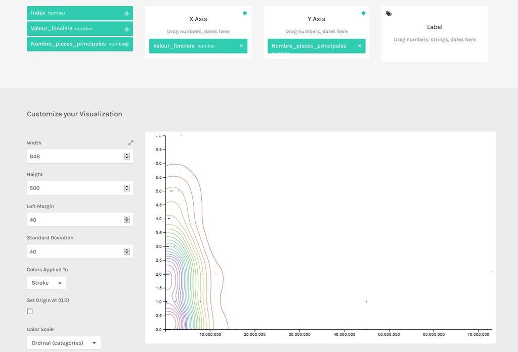

```python
from IPython.display import Image
Image("rowgraph.png", width=700)
```

# Analyse

```python
df = pd.read_pickle('df')
df.shape
df.head()
```

```
(1016090, 11)
```

|  | Date_mutation | Valeur_fonciere | Code_postal | Commune | Code_departement | Code_commune | Surface_reelle_bati | Nombre_pieces_principales | Surface_terrain | Region | code_region |
| --- | --- | --- | --- | --- | --- | --- | --- | --- | --- | --- | --- |
| 0 | 11/01/2019 | 84000.0 | 1960.0 | PERONNAS | 01 | 289 | 0.0 | 0.0 | NaN | Auvergne-Rhône-Alpes | 84 |
| 1 | 11/01/2019 | 84000.0 | 1960.0 | PERONNAS | 01 | 289 | 67.0 | 3.0 | NaN | Auvergne-Rhône-Alpes | 84 |
| 2 | 08/02/2019 | 210000.0 | 1250.0 | MONTAGNAT | 01 | 254 | 118.0 | 4.0 | 913.0 | Auvergne-Rhône-Alpes | 84 |
| 3 | 08/02/2019 | 210000.0 | 1250.0 | MONTAGNAT | 01 | 254 | 118.0 | 4.0 | 1000.0 | Auvergne-Rhône-Alpes | 84 |
| 4 | 04/04/2019 | 36000.0 | 1560.0 | SAINT-JULIEN-SUR-REYSSOUZE | 01 | 367 | 60.0 | 3.0 | 96.0 | Auvergne-Rhône-Alpes | 84 |

```python
df.nunique()
```

```
Date_mutation                  179
Valeur_fonciere              51658
Code_postal                   5491
Commune                      24398
Code_departement                95
Code_commune                   897
Surface_reelle_bati           2490
Nombre_pieces_principales       31
Surface_terrain              28492
Region                          16
code_region                     17
dtype: int64
```

## Groupby

```python
df = pd.read_pickle('df')
df.shape
df.head()
```

```
(1016090, 11)
```

|  | Date_mutation | Valeur_fonciere | Code_postal | Commune | Code_departement | Code_commune | Surface_reelle_bati | Nombre_pieces_principales | Surface_terrain | Region | code_region |
| --- | --- | --- | --- | --- | --- | --- | --- | --- | --- | --- | --- |
| 0 | 11/01/2019 | 84000.0 | 1960.0 | PERONNAS | 01 | 289 | 0.0 | 0.0 | NaN | Auvergne-Rhône-Alpes | 84 |
| 1 | 11/01/2019 | 84000.0 | 1960.0 | PERONNAS | 01 | 289 | 67.0 | 3.0 | NaN | Auvergne-Rhône-Alpes | 84 |
| 2 | 08/02/2019 | 210000.0 | 1250.0 | MONTAGNAT | 01 | 254 | 118.0 | 4.0 | 913.0 | Auvergne-Rhône-Alpes | 84 |
| 3 | 08/02/2019 | 210000.0 | 1250.0 | MONTAGNAT | 01 | 254 | 118.0 | 4.0 | 1000.0 | Auvergne-Rhône-Alpes | 84 |
| 4 | 04/04/2019 | 36000.0 | 1560.0 | SAINT-JULIEN-SUR-REYSSOUZE | 01 | 367 | 60.0 | 3.0 | 96.0 | Auvergne-Rhône-Alpes | 84 |

```python
df.groupby('Region')['Valeur_fonciere'].mean().astype(int)
```

```
Region
Auvergne-Rhône-Alpes           604344
Bourgogne-Franche-Comté        111546
Bretagne                       367836
Centre-Val de Loire           1108839
Grand Est                      158899
Guadeloupe                     350248
Guyane                         567259
Hauts-de-France                309263
La Réunion                     190594
Martinique                     564599
Normandie                      211185
Nouvelle-Aquitaine             333695
Occitanie                     2428487
Pays de la Loire               648054
Provence-Alpes-Côte d'Azur    1010730
Île-de-France                 2069234
Name: Valeur_fonciere, dtype: int32
```

```python
#rappel base python = des listes partout
df.groupby((df.Surface_terrain  > 100))['Valeur_fonciere'].mean().astype(int)
```

[output not shown]

```python
mask = (df.Surface_terrain  > 100).map({False : '< 10', True : '> 10'})
mask
```

```
0          < 10
1          < 10
2          > 10
3          > 10
4          < 10
           ...
1017149    > 10
1017150    > 10
1017151    > 10
1017152    > 10
1017153    > 10
Name: Surface_terrain, Length: 1016090, dtype: object
```

```python
df.groupby(mask)['Valeur_fonciere'].mean().astype(int)
```

```
Surface_terrain
< 10     600061
> 10    1252150
Name: Valeur_fonciere, dtype: int32
```

```python
#rappel base python = des listes partout
df.groupby(['Region' , mask])['Valeur_fonciere'].mean().astype(int).to_frame()
```

| Region | Surface_terrain | Valeur_fonciere |
| --- | --- | --- |
| Auvergne-Rhône-Alpes | < 10 | 379155 |
|  | > 10 | 783178 |
| Bourgogne-Franche-Comté | < 10 | 106836 |
|  | > 10 | 112629 |
| Bretagne | < 10 | 284861 |
|  | > 10 | 404404 |
| Centre-Val de Loire | < 10 | 229485 |
|  | > 10 | 1419036 |
| Grand Est | < 10 | 146476 |
|  | > 10 | 163950 |
| Guadeloupe | < 10 | 135328 |
|  | > 10 | 453035 |
| Guyane | < 10 | 189550 |
|  | > 10 | 662897 |
| Hauts-de-France | < 10 | 325631 |
|  | > 10 | 299821 |
| La Réunion | < 10 | 110375 |
|  | > 10 | 257177 |
| Martinique | < 10 | 201978 |
|  | > 10 | 887662 |
| Normandie | < 10 | 212624 |
|  | > 10 | 210457 |
| Nouvelle-Aquitaine | < 10 | 301158 |
|  | > 10 | 345690 |
| Occitanie | < 10 | 1511506 |
|  | > 10 | 2994645 |
| Pays de la Loire | < 10 | 813202 |
|  | > 10 | 565986 |
| Provence-Alpes-Côte d'Azur | < 10 | 718951 |
|  | > 10 | 1669693 |
| Île-de-France | < 10 | 660828 |
|  | > 10 | 5265341 |

## Describe

```python
df.Valeur_fonciere.describe().astype(int)
```

```
count       1003305
mean         983873
std         7750284
min               0
25%           56625
50%          144000
75%          258600
max      1750000000
Name: Valeur_fonciere, dtype: int32
```

```python
df.groupby('Region')['Valeur_fonciere'].describe().astype(int)
```

| Region | count | mean | std | min | 25% | 50% | 75% | max |
| --- | --- | --- | --- | --- | --- | --- | --- | --- |
| Auvergne-Rhône-Alpes | 80543 | 604344 | 5643532 | 0 | 45000 | 135500 | 255000 | 192346240 |
| Bourgogne-Franche-Comté | 34332 | 111546 | 214980 | 1 | 15000 | 62000 | 135000 | 14443174 |
| Bretagne | 66506 | 367836 | 12295913 | 1 | 45000 | 110000 | 192000 | 1750000000 |
| Centre-Val de Loire | 68977 | 1108839 | 6831860 | 1 | 42000 | 110000 | 200000 | 54257152 |
| Grand Est | 53961 | 158899 | 430790 | 0 | 25000 | 84000 | 164000 | 17100000 |
| Guadeloupe | 68 | 350248 | 911919 | 1950 | 88000 | 139850 | 213158 | 6556130 |
| Guyane | 1173 | 567259 | 1375870 | 1 | 57700 | 189000 | 310000 | 7202810 |
| Hauts-de-France | 70811 | 309263 | 1162600 | 0 | 70000 | 137000 | 218800 | 31218000 |
| La Réunion | 366 | 190594 | 283614 | 90 | 71120 | 121350 | 207098 | 2200000 |
| Martinique | 1040 | 564599 | 1265172 | 1 | 96012 | 170000 | 292000 | 5300000 |
| Normandie | 38339 | 211185 | 498732 | 1 | 61000 | 130000 | 204000 | 13720000 |
| Nouvelle-Aquitaine | 145243 | 333695 | 2987250 | 0 | 35000 | 115000 | 220000 | 221974704 |
| Occitanie | 102921 | 2428487 | 14504127 | 1 | 51000 | 130000 | 235000 | 174814352 |
| Pays de la Loire | 101079 | 648054 | 4115910 | 0 | 46500 | 122000 | 212000 | 55244924 |
| Provence-Alpes-Côte d'Azur | 59069 | 1010730 | 5969510 | 0 | 104928 | 192000 | 329923 | 60898180 |
| Île-de-France | 178877 | 2069234 | 9715891 | 0 | 165000 | 264100 | 478580 | 229583760 |

```python
df.groupby('Region').nunique()
```

| Region | Date_mutation | Valeur_fonciere | Code_postal | Commune | Code_departement | Code_commune | Surface_reelle_bati | Nombre_pieces_principales | Surface_terrain | Region | code_region |
| --- | --- | --- | --- | --- | --- | --- | --- | --- | --- | --- | --- |
| Auvergne-Rhône-Alpes | 160 | 8958 | 709 | 2902 | 12 | 519 | 679 | 19 | 7530 | 1 | 1 |
| Bourgogne-Franche-Comté | 155 | 3083 | 373 | 2121 | 8 | 637 | 445 | 17 | 7174 | 1 | 1 |
| Bretagne | 161 | 6889 | 321 | 1204 | 4 | 386 | 639 | 18 | 8725 | 1 | 1 |
| Centre-Val de Loire | 157 | 5751 | 237 | 1692 | 6 | 414 | 684 | 19 | 10212 | 1 | 1 |
| Grand Est | 153 | 5664 | 344 | 2740 | 7 | 654 | 644 | 18 | 7388 | 1 | 1 |
| Guadeloupe | 35 | 47 | 13 | 13 | 1 | 13 | 38 | 6 | 35 | 1 | 1 |
| Guyane | 117 | 397 | 16 | 16 | 1 | 16 | 161 | 8 | 597 | 1 | 1 |
| Hauts-de-France | 156 | 6932 | 639 | 3101 | 5 | 897 | 762 | 17 | 6793 | 1 | 1 |
| La Réunion | 91 | 176 | 32 | 22 | 1 | 22 | 97 | 8 | 176 | 1 | 1 |
| Martinique | 102 | 317 | 30 | 31 | 1 | 31 | 151 | 8 | 339 | 1 | 1 |
| Normandie | 153 | 3599 | 361 | 1678 | 5 | 740 | 533 | 18 | 6406 | 1 | 1 |
| Nouvelle-Aquitaine | 159 | 10984 | 627 | 3467 | 12 | 580 | 849 | 19 | 13424 | 1 | 1 |
| Occitanie | 163 | 9525 | 618 | 3088 | 13 | 562 | 636 | 21 | 9557 | 1 | 1 |
| Pays de la Loire | 157 | 8787 | 306 | 1236 | 5 | 380 | 909 | 17 | 11581 | 1 | 1 |
| Provence-Alpes-Côte d'Azur | 160 | 6011 | 340 | 721 | 6 | 230 | 520 | 20 | 4054 | 1 | 1 |
| Île-de-France | 162 | 16925 | 526 | 1299 | 8 | 669 | 1103 | 20 | 4463 | 1 | 2 |

## Categories

```python
pd.cut(df.Surface_reelle_bati, bins= [0,10,100,10000,100000]).value_counts().sort_index()
```

```
(0, 10]              2303
(10, 100]          298806
(100, 10000]       109925
(10000, 100000]       183
Name: Surface_reelle_bati, dtype: int64
```

```python
a = pd.cut(df.Surface_reelle_bati, bins= [0,10,100,1000])
df.groupby([df.code_region, a]).size()
```

```
code_region  Surface_reelle_bati
1            (0, 10]                    1
             (10, 100]                 39
             (100, 1000]                8
2            (0, 10]                    3
             (10, 100]                494
             (100, 1000]              124
3            (0, 10]                    2
             (10, 100]                434
             (100, 1000]              139
4            (10, 100]                138
             (100, 1000]               38
11           (0, 10]                  580
             (10, 100]              59092
             (100, 1000]            14356
24           (0, 10]                  116
             (10, 100]              18311
             (100, 1000]             7711
27           (0, 10]                   36
             (10, 100]               6962
             (100, 1000]             3407
28           (0, 10]                   57
             (10, 100]              12709
             (100, 1000]             5342
32           (0, 10]                  154
             (10, 100]              23710
             (100, 1000]             9707
44           (0, 10]                   96
             (10, 100]              12907
             (100, 1000]             5757
52           (0, 10]                  156
             (10, 100]              26561
             (100, 1000]            11495
53           (0, 10]                   43
             (10, 100]              16820
             (100, 1000]             8969
75           (0, 10]                  109
             (10, 100]              31730
             (100, 1000]            15254
76           (0, 10]                  195
             (10, 100]              28119
             (100, 1000]             9949
84           (0, 10]                  122
             (10, 100]              23010
             (100, 1000]             8013
93           (0, 10]                  219
             (10, 100]              24452
             (100, 1000]             5156
11           (0, 10]                  414
             (10, 100]              13318
             (100, 1000]             1987
dtype: int64
```

## stack unstack

```python
a = pd.cut(df.Surface_reelle_bati, bins= [0,10,100,1000])
a = df.groupby([df.code_region, a]).size()
```

```python
a.head()
```

```
code_region  Surface_reelle_bati
1            (0, 10]                  1
             (10, 100]               39
             (100, 1000]              8
2            (0, 10]                  3
             (10, 100]              494
dtype: int64
```

```python
a.unstack().stack().unstack().fillna(0).astype(int)
```

| Surface_reelle_bati code_region | (0, 10] | (10, 100] | (100, 1000] |
| --- | --- | --- | --- |
| 1 | 1 | 39 | 8 |
| 2 | 3 | 494 | 124 |
| 3 | 2 | 434 | 139 |
| 4 | 0 | 138 | 38 |
| 11 | 580 | 59092 | 14356 |
| 24 | 116 | 18311 | 7711 |
| 27 | 36 | 6962 | 3407 |
| 28 | 57 | 12709 | 5342 |
| 32 | 154 | 23710 | 9707 |
| 44 | 96 | 12907 | 5757 |
| 52 | 156 | 26561 | 11495 |
| 53 | 43 | 16820 | 8969 |
| 75 | 109 | 31730 | 15254 |
| 76 | 195 | 28119 | 9949 |
| 84 | 122 | 23010 | 8013 |
| 93 | 219 | 24452 | 5156 |
| 11 | 414 | 13318 | 1987 |

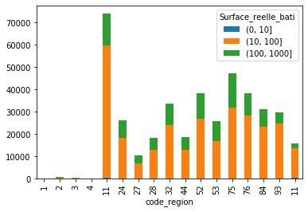

```python
a.unstack().stack().unstack().fillna(0).astype(int).plot.bar(stacked = True)
```

## pivot table

## percentiles

```python
df.Valeur_fonciere.quantile(0.1)
```

```
9900.0
```

## TimeSerie

```python
df.head(2)
```

|  | Date_mutation | Valeur_fonciere | Code_postal | Commune | Code_departement | Code_commune | Surface_reelle_bati | Nombre_pieces_principales | Surface_terrain | Region | code_region |
| --- | --- | --- | --- | --- | --- | --- | --- | --- | --- | --- | --- |
| 0 | 11/01/2019 | 84000.0 | 1960.0 | PERONNAS | 01 | 289 | 0.0 | 0.0 | NaN | Auvergne-Rhône-Alpes | 84 |
| 1 | 11/01/2019 | 84000.0 | 1960.0 | PERONNAS | 01 | 289 | 67.0 | 3.0 | NaN | Auvergne-Rhône-Alpes | 84 |

### to Date time

```python
df.Date_mutation.value_counts().sort_index()
```

```python
df['Date_mutation'] = pd.to_datetime(df['Date_mutation'])
```

### Manip dt

```python
df.Date_mutation.dt.month.value_counts().sort_index()
```

```
1     159534
2     129188
3     158287
4     132550
5     130614
6     118738
7      36411
8      35106
9      22516
10     23593
11     37440
12     32113
Name: Date_mutation, dtype: int64
```

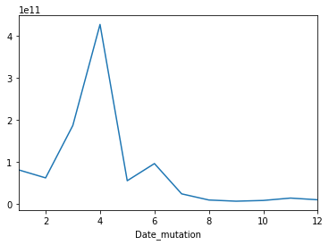

```python
grouped = df.groupby(df.Date_mutation.dt.month)
grouped.Valeur_fonciere.sum().plot()
```

```python
grouped = df.groupby([df.Region, df.Date_mutation.dt.month])
grouped.Valeur_fonciere.sum().unstack(0)
```

| Region Date_mutation | Auvergne-Rhône-Alpes | Bourgogne-Franche-Comté | Bretagne | Centre-Val de Loire | Grand Est | Guadeloupe | Guyane | Hauts-de-France | La Réunion | Martinique | Normandie | Nouvelle-Aquitaine | Occitanie | Pays de la Loire | Provence-Alpes-Côte d'Azur | Île-de-France |
| --- | --- | --- | --- | --- | --- | --- | --- | --- | --- | --- | --- | --- | --- | --- | --- | --- |
| 1 | 1.692288e+10 | 827007458.0 | 7.664594e+09 | 2.205321e+09 | 1.423699e+09 | NaN | 95441845.0 | 2.807870e+09 | 6210931.0 | 8574655.0 | 1.624314e+09 | 7.445186e+09 | 8.446212e+09 | 2.848871e+09 | 3.514198e+09 | 2.595672e+10 |
| 2 | 1.501299e+10 | 467504948.0 | 7.264876e+09 | 3.106620e+09 | 1.297083e+09 | 1285934.0 | 31876295.0 | 1.750437e+09 | 2500261.0 | 102084659.0 | 1.080898e+09 | 3.300201e+09 | 3.106473e+09 | 2.463341e+09 | 3.769507e+09 | 1.988321e+10 |
| 3 | 5.118919e+09 | 438213765.0 | 2.606012e+09 | 6.224508e+10 | 1.241505e+09 | 631200.0 | 46366061.0 | 5.173519e+09 | 8986527.0 | 45606846.0 | 8.895099e+08 | 5.773523e+09 | 2.864521e+09 | 3.285830e+09 | 2.693607e+09 | 9.437701e+10 |
| 4 | 2.592807e+09 | 588021455.0 | 2.167758e+09 | 2.151414e+09 | 1.004435e+09 | 501400.0 | 33157065.0 | 2.019759e+09 | 19653288.0 | 357073616.0 | 8.748736e+08 | 4.459546e+09 | 2.261768e+11 | 2.306691e+09 | 3.954569e+10 | 1.420422e+11 |
| 5 | 3.325764e+09 | 497327528.0 | 1.391108e+09 | 2.087862e+09 | 9.596009e+08 | 13743196.0 | 373816650.0 | 3.262502e+09 | 10782546.0 | 24591884.0 | 1.036039e+09 | 4.521660e+09 | 3.885001e+09 | 2.660984e+09 | 2.472965e+09 | 2.939376e+10 |
| 6 | 2.415797e+09 | 384301112.0 | 1.217530e+09 | 2.160898e+09 | 9.803854e+08 | 3561694.0 | 49733744.0 | 2.776640e+09 | 14008693.0 | 7157679.0 | 1.006930e+09 | 4.457653e+09 | 2.067753e+09 | 4.688463e+10 | 2.461178e+09 | 2.968282e+10 |
| 7 | 8.161176e+08 | 107135957.0 | 3.413045e+08 | 8.679506e+08 | 4.875774e+08 | 310000.0 | 3088803.0 | 1.612925e+09 | 3042700.0 | 4719022.0 | 1.992847e+08 | 1.095639e+10 | 6.544692e+08 | 5.977880e+08 | 7.490180e+08 | 7.380431e+09 |
| 8 | 6.215946e+08 | 155203578.0 | 3.196484e+08 | 3.657632e+08 | 3.138819e+08 | 405000.0 | 5543479.0 | 6.790591e+08 | 673000.0 | 3862612.0 | 4.222736e+08 | 1.496464e+09 | 8.316985e+08 | 6.746116e+08 | 9.996684e+08 | 3.323234e+09 |
| 9 | 3.077962e+08 | 92353223.0 | 2.346562e+08 | 3.127133e+08 | 1.359353e+08 | 600000.0 | 3025830.0 | 2.280313e+08 | 801000.0 | 4433000.0 | 2.299699e+08 | 6.360441e+08 | 3.442053e+08 | 5.288363e+08 | 3.869771e+08 | 3.935959e+09 |
| 10 | 3.686190e+08 | 78905784.0 | 2.514369e+08 | 2.689174e+08 | 1.103059e+08 | 140450.0 | 6324599.0 | 7.640571e+08 | 1223658.0 | 3802000.0 | 1.375705e+08 | 6.730955e+08 | 3.765548e+08 | 3.233020e+08 | 4.083457e+08 | 5.360674e+09 |
| 11 | 7.062001e+08 | 104132968.0 | 6.806673e+08 | 3.274615e+08 | 4.059787e+08 | 2620000.0 | 12127576.0 | 4.689942e+08 | 1062500.0 | 18532131.0 | 4.242085e+08 | 3.363101e+09 | 6.323149e+08 | 9.211867e+08 | 1.228493e+09 | 5.485954e+09 |
| 12 | 4.662614e+08 | 89493870.0 | 3.237753e+08 | 3.844368e+08 | 2.140143e+08 | 18000.0 | 4893832.0 | 3.554466e+08 | 812615.0 | 6745730.0 | 1.707789e+08 | 1.384105e+09 | 5.563159e+08 | 2.008605e+09 | 1.473166e+09 | 3.316422e+09 |

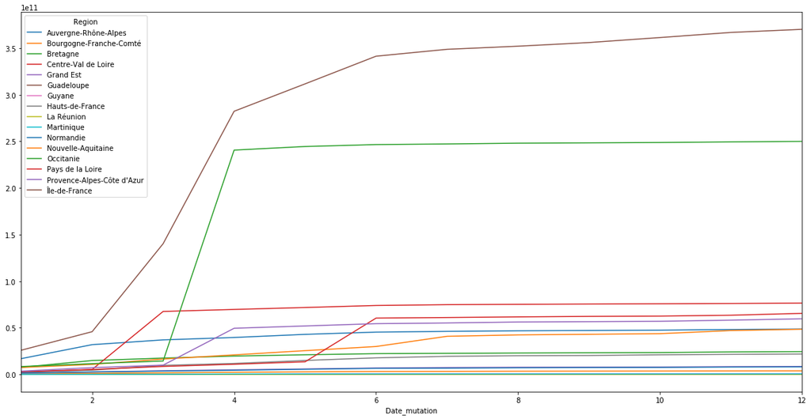

```python
grouped = df.groupby([df.Region, df.Date_mutation.dt.month])
grouped.Valeur_fonciere.sum().unstack(0).cumsum().plot(figsize = (20,10) )
```

### rolling

```python
dfparis = df[df.Region == 'Île-de-France']
```

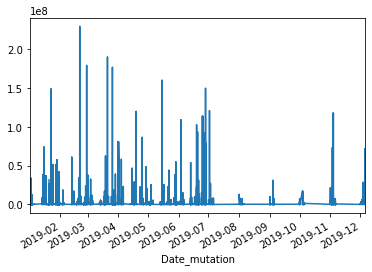

```python
dfparis.set_index('Date_mutation').Valeur_fonciere.plot()
```

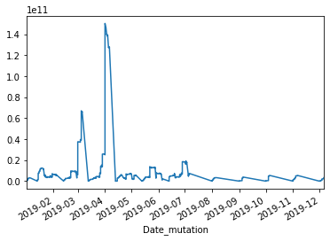

```python
a = dfparis.set_index('Date_mutation').sort_index()
a.Valeur_fonciere.rolling('7d').sum().plot()
```

# Export MAXX

## lambda

## function

## swagger

## widget

On peut télécharger ce denier (environ 300mo) et avoir divers exercices listés ci-des sous: Transformation de fichier DVF à .CSV (où transformation par nos soins en amont ? Data Cleaning: on a X colonnes, on s'intéresse à seulement 9 d'entre elles: Exemple ici: Date mutation Valeur fonciere Code postal Commune Code departement Code commune Surface reelle bati Nombre pieces principales Surface terrain 3. On peut faire des exercices de grouping relativement basiques: par département et par commune (on a le code du département) et le code postal. 4. On peut enrichir ce fichier avec le concept de région (on crée ou on fait créer un fichier cartographiant les régions actuelles (ou anciennes, ou les deux) avec les départements. On demande de récupérer ce fichier et d'enrichir le présent (RegionMappingEnrichService si je devais parler en langage SG). 5. On peut même imaginer des recalcules de moyenne de valeur foncière par région avant et après la réforme (donc si on enlève ou ajoute des départements). Avec un calcul de variation, etc. 6. Introduction aux fonctions de bases : moyennes, time-series, min/max par axe, écart (variance) à la moyenne par rapport à un département/Région de base (exemple: écart du département Lorraine par rapport à Yvelines). 7. Travail sur les déciles, quartiles, "percentiles" (à 1%, 5% et 10%), etc. 8. Extrapolation linéaire sur un département selon la tendance des valeurs sur l'année à +3 mois. 9. Gros zoom sur le drill-down: demander d'agréger les chiffres niveau national et par région. Puis de produire un graphique. Puis d'introduire la notion de départements qui permettra par la suite de cliquer sur un élément de graph (imaginons un camembert) et d'avoir la décomposition de ladite région en départements. Cela fera le lien avec la structure analytique de la banque.

# Pycharm

## presentation

## export function to pycharm

# refactorer code

## basique

## class

## module

## TP

# dev

## pytest

## git

# Drill Down

# Bonus

## Scrap ?

## GeoLoc